# Hands-on Tutorial: Classifying PBMC scRNA-seq Data (No Packages Needed)

Keita Iida

2025-09-02

# 1 Objective of this hands-on tutorial

This tutorial introduces basic single-cell RNA-seq (scRNA-seq) data analysis using only built-in R functions (i.e. functions that are available without installing any extra packages).

The goal is not to fully master modern analysis pipelines, but rather to gain hands-on experience with the fundamentals: data inspection, quality control, normalisation, clustering, and annotation.

Through this hands-on approach, you’ll get a sense of how scRNA-seq analysis works and how it can be used to understand what happens in our cells during disease.

# 2 Introduction

In this tutorial, we analyze single-cell RNA sequencing (scRNA-seq) data obtained from peripheral blood mononuclear cells (PBMCs), which are a type of immune cell found in the blood, of donors with and without bacterial sepsis ([Reyes et al., Nature Medicine, 2020](https://pubmed.ncbi.nlm.nih.gov/32066974/)).

The original data has been reduced for educational purposes. The reduced dataset combines scRNA-seq data from a total of 41 donors. These donors were categorized into four groups: control, infection without sepsis, moderate sepsis, and severe sepsis.

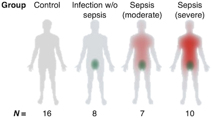

# 3 Preparation

## 3.1 Working directory

First of all, let’s check the current working directory using the following command:

```r
getwd()
```

```
[1] "/Users/kiida/ICL2025/scratch"
```

This output indicates that your current working directory is `scratch/`. Therefore, any R history or files you save without specifying a full path will be stored within this `scratch/` directory.

If the reported directory is not what you expect, please close RStudio, verify the location of your project files, and then restart RStudio.

## 3.2 Data import

Create a new folder “data/” in the current working directory, download the demo data, and save them under “data/”

First, create a new folder called `"data/"` in your current working directory. Then, download the demo data files and save them into the `"data/"` folder.

```r
dir.create("data", showWarnings = FALSE)

giturl <- "https://raw.githubusercontent.com/keita-iida/EASY1CELL/main/data/pbmc_counts.txt"
download.file(giturl, destfile = "data/pbmc_counts.txt", mode = "wb")

giturl <- "https://raw.githubusercontent.com/keita-iida/EASY1CELL/main/data/pbmc_metadata.txt"
download.file(giturl, destfile = "data/pbmc_metadata.txt", mode = "wb")
```

You can then read the data using the following commands:

```r
counts <- read.table("data/pbmc_counts.txt", row.names = 1, header = TRUE)
meta <- read.table("data/pbmc_metadata.txt", row.names = 1, header = TRUE)
```

Here,

- `counts` contains gene expression data: rows are genes, columns are cells.
- `meta` contains metadata for each cell: rows are cells, columns are annotations such as donor or group.

One can check the data by clicking the R object shown in the top-right panel, which will show something like the following:

[figure not shown]

You can also use `View()` to open the data in a spreadsheet-like window. For example,

```r
View(counts)
```

|  | GTACTCCGTCTAGGTT.17 | TCTGAGAGTTCAACCA.15 | AGCGTCGGTTCCGGCA.11 |
| --- | --- | --- | --- |
| UBE2E2 | 1 | 0 | 0 |
| SH3YL1 | 0 | 0 | 1 |
| HMGXB4 | 0 | 0 | 0 |
| CYSTM1 | 0 | 0 | 0 |
| ANP32B | 1 | 0 | 0 |

## 3.3 Class of R objects

R objects have a ‘class’. Let’s check the class of the R object `meta`.

```r
class(meta)
```

This will output:

```
[1] "data.frame"
```

This indicates that the object `meta` is of the `data.frame` type. `data.frame` is a common way to store table-like data in R:

|  | Donor | Group |
| --- | --- | --- |
| GTACTCCGTCTAGGTT-17 | C2P18 | Sepsis_moderate |
| TCTGAGAGTTCAACCA-15 | C2P10H | Control |
| AGCGTCGGTTCCGGCA-11 | P02H | Control |
| GGGATGATCTTTAGGG-13 | C2P10 | Sepsis_severe |
| AGATTGCAGATATGGT-15 | C2P15 | Sepsis_moderate |
| TTGAACGGTTCCACAA-13 | C2P13 | Sepsis_severe |

Next, let’s check the type of `counts`:

```r
class(counts)
```

This also outputs:

```
[1] "data.frame"
```

We could proceed as is, but since the R object `counts` is a matrix data, let’s change its class into “matrix” with the following command so that it behaves consistently in numerical calculations:

```r
counts <- as.matrix(counts)
```

Now, if you run:

```r
class(counts)
```

You will see:

```
[1] "matrix" "array"
```

indicating that `counts` is now of the matrix type. Although `data.frame` and `matrix` are similar, be aware that there are specific operations that can only be performed on each type.

## 3.4 Data size

You can check the dimensions (size) of an R object using the following command:

```r
dim(counts)
```

This will output:

```
[1] 637 545
```

This means that the `counts` object is in a matrix format with 637 genes and 545 cells.

Similarly, if you run:

```r
dim(meta)
```

You will see:

```
[1] 545   2
```

This indicates that the `meta` metadata contains information for 545 cells.

Let’s check if the cell barcodes of `counts` and `meta` are the same, which are the column and row names, respectively. You can do this with the following command:

```r
identical(colnames(counts), rownames(meta))
```

This will output:

```
[1] FALSE
```

Why? Observe closely to see what the difference is. If you run:

```r
head(colnames(counts))  # head() and tail() functions in R are often used to
                        # read the first and last n rows.
```

You’ll get:

```
[1] "GTACTCCGTCTAGGTT.17" "TCTGAGAGTTCAACCA.15" "AGCGTCGGTTCCGGCA.11" "GGGATGATCTTTAGGG.13"
[5] "AGATTGCAGATATGGT.15" "TTGAACGGTTCCACAA.13"
```

And if you run:

```r
head(rownames(meta))
```

You’ll see:

```
[1] "GTACTCCGTCTAGGTT-17" "TCTGAGAGTTCAACCA-15" "AGCGTCGGTTCCGGCA-11" "GGGATGATCTTTAGGG-13"
[5] "AGATTGCAGATATGGT-15" "TTGAACGGTTCCACAA-13"
```

Notice that the hyphen “-” changed into period “.”. This behavior actually stems from the `read.table()` function during the initial data import. It’s important to be aware that R often performs such automatic modifications, which can occasionally lead to unexpected results.

Another instance of this automatic modification occurs when extracting a single column from a matrix or data frame. Let’s extract the first column from `counts`:

```r
test <- counts[, 1]
```

Does `test` retain its matrix class? No:

```r
class(test)
```

```
[1] "integer"
```

Here, `integer` indicates that the object `test` is now a vector of integers. You can avoid the class change of `test` by the following code:

```r
test <- counts[, 1, drop = FALSE]
```

Then, you’ll get

```r
class(test)
```

```
[1] "matrix" "array"
```

Now, let’s edit the cell barcode names in `meta`. We want to change the hyphens to periods. We can do this as follows:

```r
rownames(meta) <- gsub("-", ".", rownames(meta))
```

where `gsub()` is a function that searches for a pattern in text and replaces it with something else. After running this, if you execute:

```r
identical(colnames(counts), rownames(meta))
```

You will now see:

```
[1] TRUE
```

This indicates that they are now an exact match, including the order.

# 4 Observation

A statistician once said **“Data analysis tends to fail if you try to take shortcuts.”**

This seems to be a truth. In omics data analysis, visualising the computational results is a very important task, and neglecting it can lead you into statistical traps.

Imagine you test whether a gene is expressed differently in two groups and get a p-value of 0.01.  
Is that enough to say the difference is real? We’ll explore this question later in the tutorial.

## 4.1 Many zeros in scRNA-seq data

There are two main experimental protocols for scRNA-seq: well-based and droplet-based. Here, we’ll analyze demo data generated using a droplet-based scRNA-seq protocol, a method widely adopted by companies like 10x Genomics. Looking forward to the second Tutorial, droplet-based scRNA-seq is briefly a method for capturing single cells in the following way:

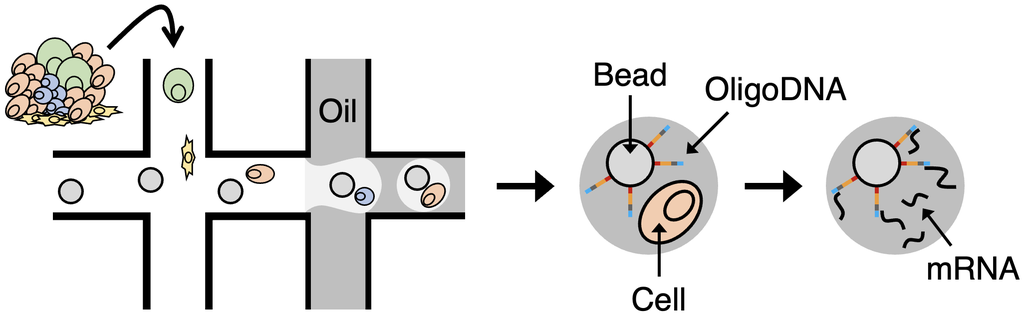

As you can see in `counts`, the data contains many zeros, which we describe as being **“sparse.”** The abundance of zeros in droplet scRNA-seq data is largely attributed to the low sampling efficiency of the sequencer, meaning non-zero values can also be underestimated ([Svensson, Nature Biotechnology, 2020](https://pubmed.ncbi.nlm.nih.gov/31937974/)). This reference clearly shows how sparse scRNA-seq data can be, based on experimental evidence.

## 4.2 Naive analysis

Before performing standard scRNA-seq data analysis, let’s examine the results we get without any specific processing. This will help understand the importance of the subsequent data processing steps.

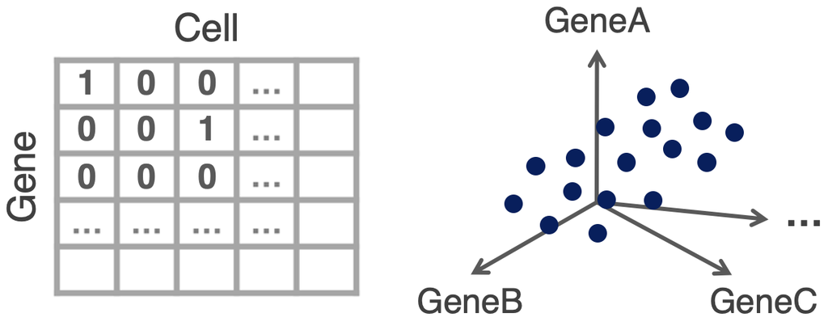

Although the above figure conceptually depicts this Euclidean space, visualizing such high-dimensional data directly is impossible. Therefore, we use dimensionality reduction to estimate lower-dimensional manifolds (like planes or curved surfaces) that approximate the data distribution. One of the most commonly used methods is Principal Component Analysis (PCA).

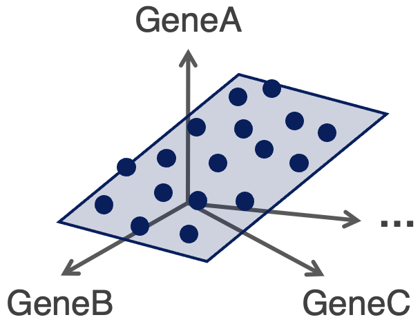

R provides the function `prcomp()` for easy Principal Component Analysis (PCA).

```r
cellxgene <- t(counts)
res_pca <- prcomp(cellxgene)
```

Here, `cellxgene <- t(counts)` transposes the gene-by-cell count matrix and stores the result in the R object `cellxgene`. This is because the `prcomp()` function expects the variables (in this case, genes) to be in the columns.

You can see the contents of `res_pca` by using `View(res_pca)` or by clicking on the R object in RStudio. You see slots such as “sdev”, “rotation”, “center”, “scale”, and “x”.

```r
names(res_pca)
```

```
[1] "sdev"     "rotation" "center"   "scale"    "x"
```

We’ll discuss the details of each slot later. For now, let’s visualize the cell data projected onto the first two **principal components PC1 and PC2**. The projected coordinates, termed **principal component scores** are stored in the `$x` slot of `res_pca`.

```r
plot(res_pca$x[, c(1, 2)])
```

In R, `c()` is used to create vectors, often representing mathematical vectors like `(1, 2)` or character vectors like `("A", "B", "C")`. Therefore, `res_pca$x[, c(1, 2)]` selects all rows and the first and second columns of `res_pca$x`.

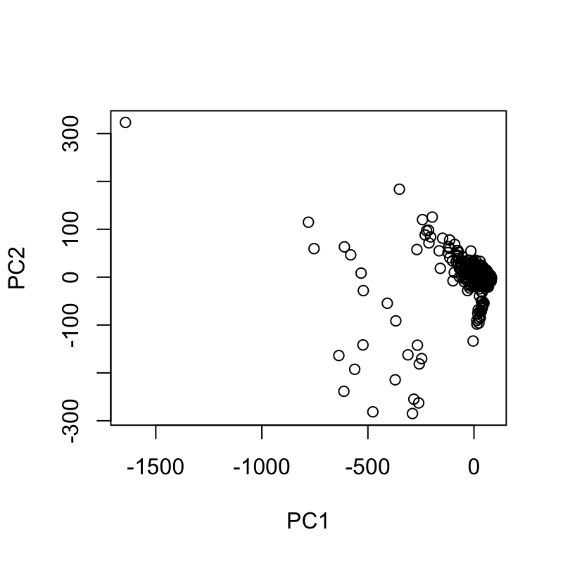

Hmm…, we can only see the cells distributed in PC1-PC2 axes, which is difficult to interpret. But this visualization is important to understand the data.

## 4.3 Save point (1)

Save the R objects. The following creates a “Backup/” folder in your working directory and saves the R objects.

```r
dir.create("backup", showWarnings = FALSE)
saveRDS(counts, file = "backup/001_pbmc_counts.rds")  # File name is arbitrary.
saveRDS(meta, file = "backup/001_pbmc_meta.rds")      # File name is arbitrary.
```

To resume later:

```r
counts <- readRDS("backup/001_pbmc_counts.rds")
meta <- readRDS("backup/001_pbmc_meta.rds")
```

# 5 Data quality control

Quality control (QC) is a crucial step in scRNA-seq data analysis, involving the removal of potentially low-quality gene and cell data.

Following a standard procedure in the scRNA-seq analysis package [Seurat](https://satijalab.org/seurat/), we will perform a thorough QC process in three steps:

1. removing low-quality genes
2. removing low-quality cells
3. removing lowly expressed genes

## 5.1 QC for genes

First, we will exclude low-quality genes that have zero expression in more than 99.9 % of all cells. The following code might look complex at first glance, but it can be understood step by step.

```r
indices_gene <- which(rowSums(counts == 0) / ncol(counts) > 0.999)  # (QC1-1)
counts_qc1 <- counts[-indices_gene, ]                               # (QC1-2)
```

The code `# (QC1-1)` identifies the indices of genes where the proportion of zero counts is greater than 0.999 (99.9%) and stores these indices in the `indices_gene` variable: Here, `rowSums(counts == 0)` calculates the total number of zero counts per gene (row), and `ncol(counts)` is the total number of cells.

Using `indices`, you can see the corresponding gene names by the following code:

```r
head(rownames(counts)[indices_gene])  # head() and tail() functions are often
                                      # used to read the first and last n rows.
```

```
[1] "RP11-403I13.5" "TRIM54"        "ARPP21"        "RP11-586D19.1" "SLC22A23"
[6] "TRGV8"
```

The code `# (QC1-2)` removes the rows (genes) at the identified indices from the original `counts` matrix, creating the filtered `counts_qc1`. R’s indexing capabilities allow for direct removal of rows based on their position.

**FAQ:** How can we determine the 99.9 % threshold?

**Answer:** This threshold is somewhat arbitrary, but that’s okay—as long as we document our steps clearly to ensure reproducibility. However, excessively arbitrary values might raise questions about their justification.

## 5.2 QC for cells

Next, for each cell, we will examine the total number of reads.

```r
meta$nReads <- colSums(counts_qc1)
```

Since `meta` is a `data.frame` object, we can add a new column, `nReads`, containing the total reads per cell calculated by `colSums(counts_qc1)`. For `data.frame` objects, columns can be accessed using the `$` followed by the column name.

You can see the results by `View(meta)`:

[output not shown]

Next, we will calculate the proportion of reads mapping to mitochondrial genes.

```r
# Identify rows corresponding to mitochondrial genes.
mt_genes <- grepl("^MT-", rownames(counts_qc1))             # (QC2-1)

# Calculate total mitochondrial counts per cell.
mt_counts <- colSums(counts_qc1[mt_genes, , drop = FALSE])  # (QC2-2)

# Calculate total counts per cell.
total_counts <- colSums(counts_qc1)                         # (QC2-3)

# Calculate the percentage of mitochondrial reads per cell.
meta$percMT <- 100 * mt_counts / total_counts               # (QC2-4)
```

The code `# (QC2-1)` identifies genes whose names start with “MT-” (a common convention for human mitochondrial genes), returning a logical vector of the same length as the number of genes Note that `^` before `"MT-"` is a special character in **regular expressions**, a notation that combines special symbols to describe string patterns.

Please also note that mouse gene symbols typically have a capital first letter and lowercase letters for the rest, with the exception of mitochondrial genes which use a lowercase ‘mt-’ prefix (e.g., ‘MT-ND1’ for human, ‘mt-Nd1’ for mouse).

The code `# (QC2-2)` calculates the total mitochondrial mRNA count for each cell. It does this by selecting the rows in `counts_qc1` that correspond to mitochondrial genes (mt_genes being `TRUE`) and then summing the expression values across these genes for each cell (column). The argument `drop = FALSE` ensures that the result remains a matrix even if only one mitochondrial gene is identified.

The code `# (QC2-3)` calculates the total number of reads for each cell.

The code `# (QC2-4)` calculates the percentage of reads originating from mitochondrial genes for each cell and stores it in the `percMT` column of the `meta` data frame.

Now that we have generated two QC metrics, `meta$nReads` and `meta$percMT`, let’s visualize them using a scatter plot.

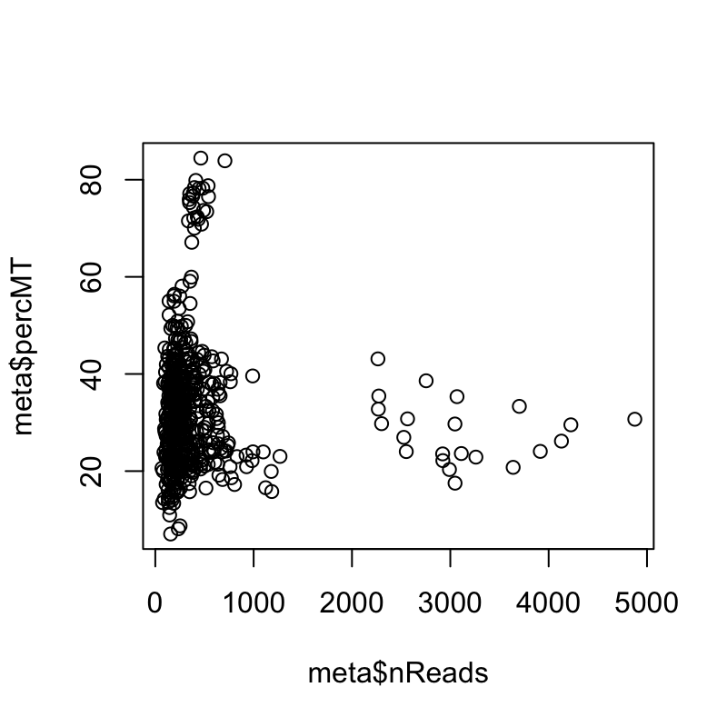

```r
plot(meta$nReads, meta$percMT)
```

From the plot, we can observe a population of cells with unusually high values for `meta$nReads` (x-axis). These are likely **doublets**, representing data from droplets containing two or more cells, which typically have an unusually high total read count.

We can also see a population of cells with unusually high values for `meta$percMT` (y-axis). These cells are often identified as dying cells, characterized by a high proportion of reads mapping to mitochondrial genes.

Additionally, “cell” data with unusually low values for `meta$nReads` is also generally considered noise, which we will not refer to in this tutorial.

Let’s remove these low-quality cells from `counts_qc1` and `meta`. Based on the scatter plot, we will exclude cells where `meta$nReads` is greater than 2000 or `meta$percMT` is greater than 60.

```r
indices_cell <- which(meta$nReads > 2000 | meta$percMT > 60)
counts_qc2 <- counts_qc1[, -indices_cell]
meta_qc2 <- meta[-indices_cell, ]
```

Again, visualize these QC metrics.

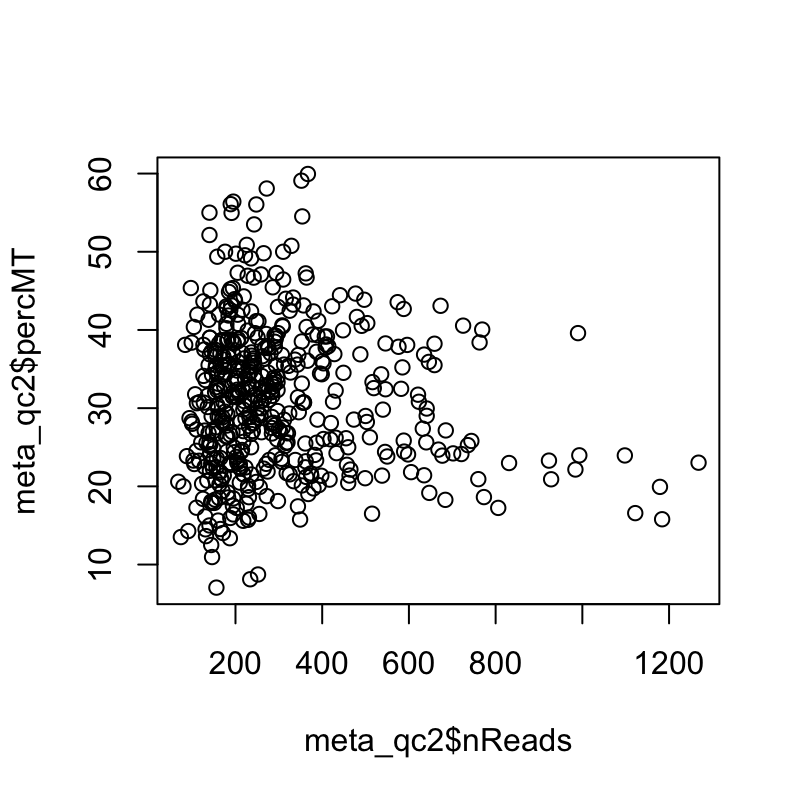

```r
plot(meta_qc2$nReads, meta_qc2$percMT)
```

**Additional exercises:** To further rationalize the threshold values used above, it would be beneficial to add histograms to the scatter plot. However, the R code for this can be slightly complex. In such cases, we can utilize R functions defined in external files.

Import the function file for a scatter plot with histograms from the following URL:

```r
# Create a new folder "R/" in the current working directory.
dir.create("R", showWarnings = FALSE)

# Download myplot.R from the following GitHub URL and save it under R/.
giturl <- "https://raw.githubusercontent.com/keita-iida/EASY1CELL/main/R/myplot.R"
local_path <- file.path("R", "myplot.R")
download.file(giturl, destfile = local_path, mode = "wb") # mode = "wb" is for Windows OS.

# Load the file to make the function available.
source(local_path)
```

You should now see a function object named `scatter_w_histogram` added to the upper right panel of RStudio (Environment pane). If you open it, you’ll see various lines of code, but you don’t need to worry about them for now.

Using this function, you can visualize the QC metrics from meta as follows:

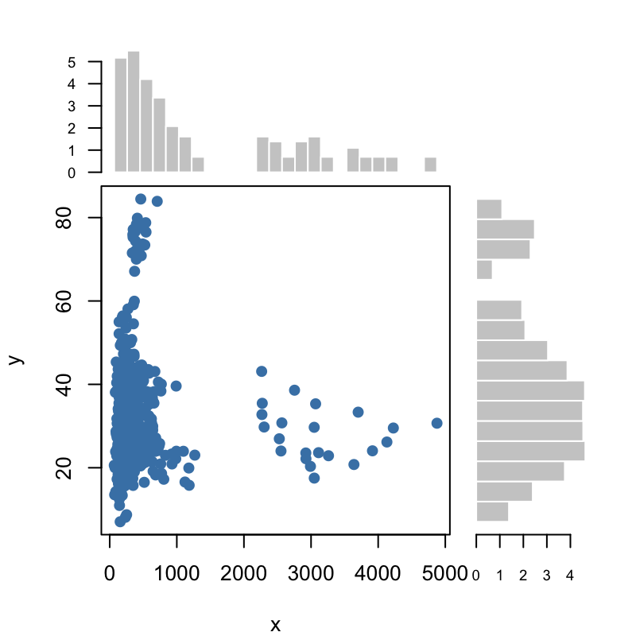

```r
df <- data.frame(meta$nReads, meta$percMT)
scatter_w_histogram(df, logscale = TRUE)
```

This plotting function modifies R’s graphics environment, so please restore it to the default settings using the following command:

```r
dev.off()
```

## 5.3 QC for genes (second)

Finally, for each gene, we will calculate the average RNA count across all cells, generate an elbow plot, and remove genes with unusually low average expression.

The following code generates such an elbow plot:

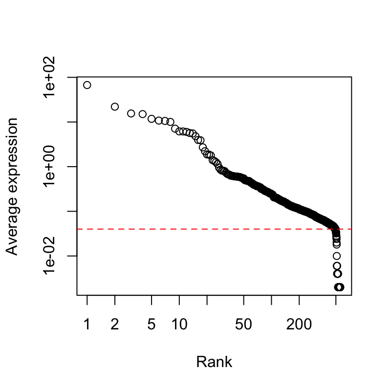

```r
# Calculate the average RNA count across all cells for each gene and sort the
# value in decreasing order.
average_expressions <- rowMeans(counts_qc2)
average_expressions_sorted <- sort(average_expressions, decreasing = TRUE)

# Prepare x (rank) and y (average expression)
x <- seq_along(average_expressions_sorted)
y <- average_expressions_sorted

# Generate an eblow plot in log-log scale
plot(x, y, log = "xy", xlab = "Rank", ylab = "Average expression")
abline(h = 0.04, col = "red", lty = 2)
```

Now, we will remove genes with unusually low average expression based on the elbow plot. We’ll use a threshold of 0.04 on the average expression.

```r
indices2_gene <- which(average_expressions >= 0.04)
counts_qc3 <- counts_qc2[indices2_gene, ]
meta_qc3 <- meta_qc2
```

At the end of this section, let’s check the dimensions of `counts_qc3`:

```r
dim(counts_qc3)
```

This will output:

```
[1] 496 500
```

This indicates that 496 genes and 500 cells have been retained after this round of quality control.

## 5.4 Save point (2)

Save the R objects.

```r
saveRDS(counts_qc3, file = "backup/002_pbmc_counts_afterQC.rds")
saveRDS(meta_qc3, file = "backup/002_pbmc_meta_afterQC.rds")
```

To resume later:

```r
counts_qc3 <- readRDS("backup/002_pbmc_counts_afterQC.rds")
meta_qc3 <- readRDS("backup/002_pbmc_meta_afterQC.rds")
```

# 6 Normalisation

In single-cell RNA sequencing (scRNA-seq), the number of reads (or counts) captured from each cell can vary a lot. This means that, even if two cells have the same biological activity, one might look like it has higher gene expression just because it had more reads overall.

Normalisation is the process of adjusting for this difference, so we can fairly compare gene expression across cells. It also helps avoid giving too much weight to genes that are very highly expressed.

Here, we use a simple method that changes the scale of the data by using a mathematical function called the logarithm (i.e., `log()` or `log1p()` in R). Before doing this, we first make sure that each cell is adjusted to the same total count, so they are on equal footing.

## 6.1 Log normalisation with a scaling factor

A standard package [Seurat](https://satijalab.org/seurat/) adopts the following normalisation method:

```r
# 1. Calculate total counts per cell (i.e., per column).
cell_totals <- colSums(counts_qc3)

# 2. Scale counts so that each cell sums to 10,000 (= 1e4).
counts_scaled <- t(t(counts_qc3) / cell_totals * 1e4)

# 3. Log-transform (log(1 + x)) the scaled matrix.
counts_log <- log1p(counts_scaled)
```

We scale all cells to have the same total count (e.g., 10,000), which removes the effect of how many reads each cell happened to get. Then, we apply a log transformation to make the differences in gene expression easier to work with, especially for downstream analysis like clustering or visualisation.

# 7 Principal component analysis

## 7.1 R function prcomp()

Using `counts_log`, let’s perform PCA again.

```r
cellxgene <- t(counts_log)
res_pca <- prcomp(cellxgene, scale = TRUE)
```

Here, the argument `scale = TRUE` in `prcomp` indicates that Principal Component Analysis (PCA) is performed on the `cellxgene` matrix after scaling each column (across cells) to have a mean of 0 and a variance of 1.

Inspect the contents of `res_pca`:

```r
names(res_pca)
```

```
[1] "sdev"     "rotation" "center"   "scale"    "x"
```

- **sdev:** “Standard deviation of each principal component.” This shows how much variation each principal component explains. Bigger numbers mean more important components. (Mathematically: `sdev^2` gives the eigenvalues of the covariance matrix)
- **rotation:** “The directions of the principal components.” This is a matrix showing how each original gene contributes to each principal component. Think of it like the weights or importance of each gene in each PC. (Mathematically: Each column is an eigenvector of the covariance matrix)
- **x:** “The data in the new coordinate system.” This is the transformed data: each row is a cell, and each column is a principal component.

Visualize the PCA result:

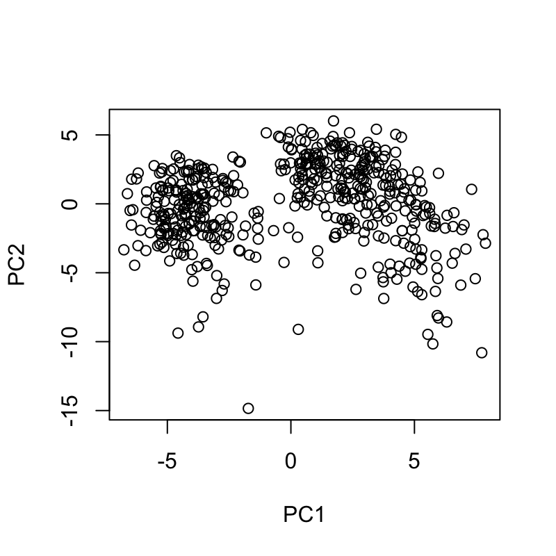

```r
plot(res_pca$x[, c(1, 2)])
```

From this PCA plot, you will likely observe two major cell populations. In fact, one of these clusters is monocytes, and the other represents the remaining immune cell populations like B, T, and NK cells. Honestly speaking, I’ve designed this demo data to reflect patterns observed in the original, well-annotated datasets.

We’ll later learn how to predict which of these clusters are the monocytes, a type of immune cell crucial in inflammation, such as during sepsis.

## 7.2 Batch effects

When analyzing scRNA-seq data from multiple donors or experiments, we need to be careful about **batch effects**.

A batch effect is a type of technical variation that arises not from biology, but from differences in how the data were collected — for example, differences in sample preparation, sequencing time, or lab conditions. These effects can accidentally make groups of cells look different from each other, even if they are biologically similar.

To check for possible batch effects in our data, one of the simplest and most useful steps is to label each cell by its donor or patient group on the PCA plot we just made.

This will help us see whether the separation we observe in the PCA plot reflects biological variation or technical differences between donors.

In this section, we will learn how to add these labels to the PCA plot.

**For a beginner:** Each donor is identified by a label such as “C2P01”, “P667”, etc. To handle such categorical information in R, we use a data structure called a **factor**. A factor is a way of storing categorical variables with fixed levels, which is useful for grouping and colouring.

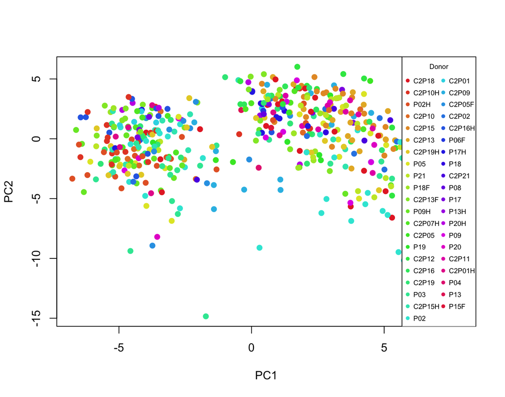

```r
# Get PCA coordinates (PC1 and PC2).
pc_scores <- res_pca$x[, c(1, 2)]
cell_names <- rownames(pc_scores)

# Reorder meta data to match the PCA cell order.
meta_ordered <- meta_qc3[cell_names, ]
donor_labels <- meta_ordered$Donor

# Convert Donor to factor for consistent group handling.
donor_levels <- unique(donor_labels)
donor_factor <- factor(donor_labels, levels = donor_levels)

# Generate n distinguishable colours using base R's rainbow().
# The 's' and 'v' parameters control saturation and brightness (for visibility).
donor_colours <- rainbow(length(donor_levels), s = 0.8, v = 0.9)
cell_colours <- donor_colours[as.integer(donor_factor)]

# Plot the PCA results.
plot(pc_scores, col = cell_colours, pch = 19, xlab = "PC1", ylab = "PC2")

# Add a legend.
legend("topright", legend = donor_levels, col = donor_colours, pch = 19,
       cex = 0.6, ncol = 2, title = "Donor")
```

In the current PCA plot, we do not observe any clear clustering by donor. This suggests that there is no strong batch effect in this dataset, at least based on the donor information.

Similarly, check the group labels (i.e., Control, Infection, Sepsis_moderate, and Sepsis_severe).

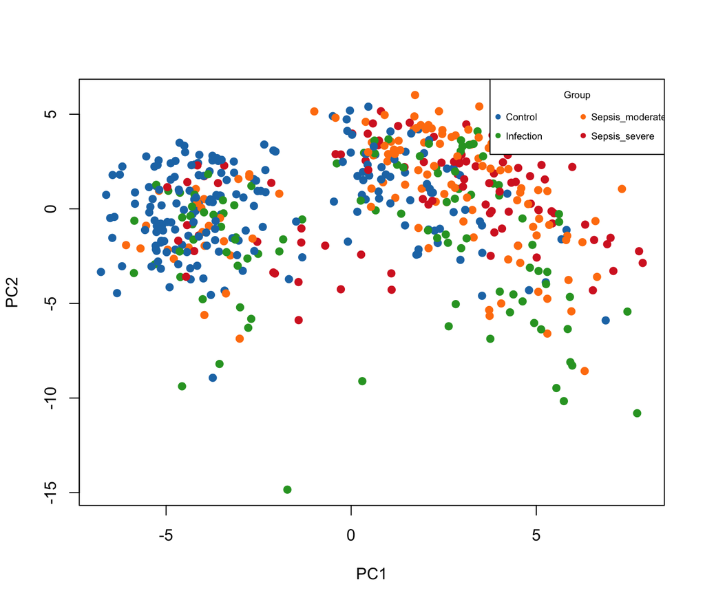

```r
# Reorder meta data to match the PCA cell order.
group_labels <- meta_ordered$Group

# Convert Group to factor with the desired order of disease progression.
group_levels <- c("Control", "Infection", "Sepsis_moderate", "Sepsis_severe")
group_factor <- factor(group_labels, levels = group_levels)

# Define colours representing inflammation severity (cool → warm)
# Blue: control, Green: infection, Orange: moderate sepsis, Red: severe sepsis
group_colours <- c("Control" = "#1f77b4",         # Blue
                   "Infection" = "#2ca02c",       # Green
                   "Sepsis_moderate" = "#ff7f0e", # Orange
                   "Sepsis_severe" = "#d62728")   # Red
cell_colours <- group_colours[as.integer(group_factor)]

# Plot the PCA results.
plot(pc_scores, col = cell_colours, pch = 19, xlab = "PC1", ylab = "PC2")

# Add a legend.
legend("topright", legend = group_levels, col = group_colours, pch = 19,
       cex = 0.6, ncol = 2, title = "Group")
```

In contrast, when colouring the cells by Group, we notice a slight tendency for cells from sepsis donors to appear more on the right-hand side of the plot.

This may suggest that the cluster on the right contains cells with inflammatory characteristics, and that these cells are more common in sepsis samples.

**Note1: Computational methods to reduce batch effects**  
When working with scRNA-seq or bulk RNA-seq data from multiple experiments or donors, we often need to combine datasets.  
However, this can introduce **batch effects** — technical differences that distort biological comparisons.

To reduce these effects while merging datasets, we use a process called **data integration**.  
In recent years, many integration methods have been developed around the world for both bulk and single-cell RNA-seq.

In single-cell analysis, an R package called **Harmony** has become especially popular ([Korsunsky et al., Nature Methods, 2019](https://www.nature.com/articles/s41592-019-0619-0)).  
It is widely used because it runs quickly and uses less memory compared to other methods.

**Note2: Experimental methods to reduce batch effects**  
Besides computational methods, there are also experimental strategies to reduce batch effects.  
One such method is called **multiplexing**.

In multiplexing, cells from different batches are labelled with unique barcodes, and then mixed together before sequencing.  
After sequencing, the data can be separated back into batches using these barcodes — a process called **demultiplexing**.

In fact, the sepsis dataset used in this tutorial was generated using a multiplexing strategy. This is likely why we observe very little batch effect in the donor-level PCA plot.

## 7.3 Principal component loadings

Running PCA, we get two useful information: **PC scores** and **PC loadings**.

Earlier, we treated cells as observations and genes as variables, and performed PCA using `prcomp(cellxgene, scale = TRUE)`.  
This means:

- **PC scores** are values assigned to **cells**.
- **PC loadings** are values assigned to **genes**.

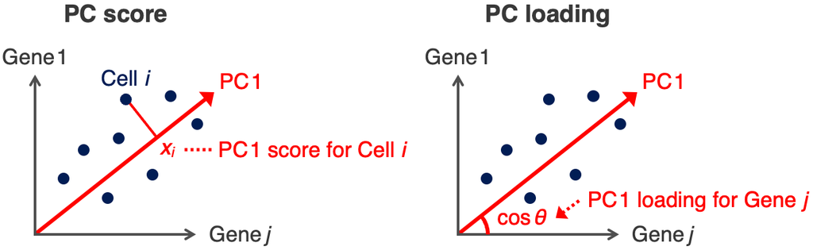

In the PCA plot, each point represents a cell.  
Its position along the PC1 axis is given by the **PC1 score for that cell**.

On the other hand, PC loadings describe how strongly each gene is correlated to a principal component.  
For example, the **PC1 loading for gene *j*** shows how much gene *j* contributes to the PC1 axis.

In this section, we will extract PC1 loadings from the PCA results and visualise the top contributing genes.  
Below is an R Code for plotting genes with the highest PC1 loadings:

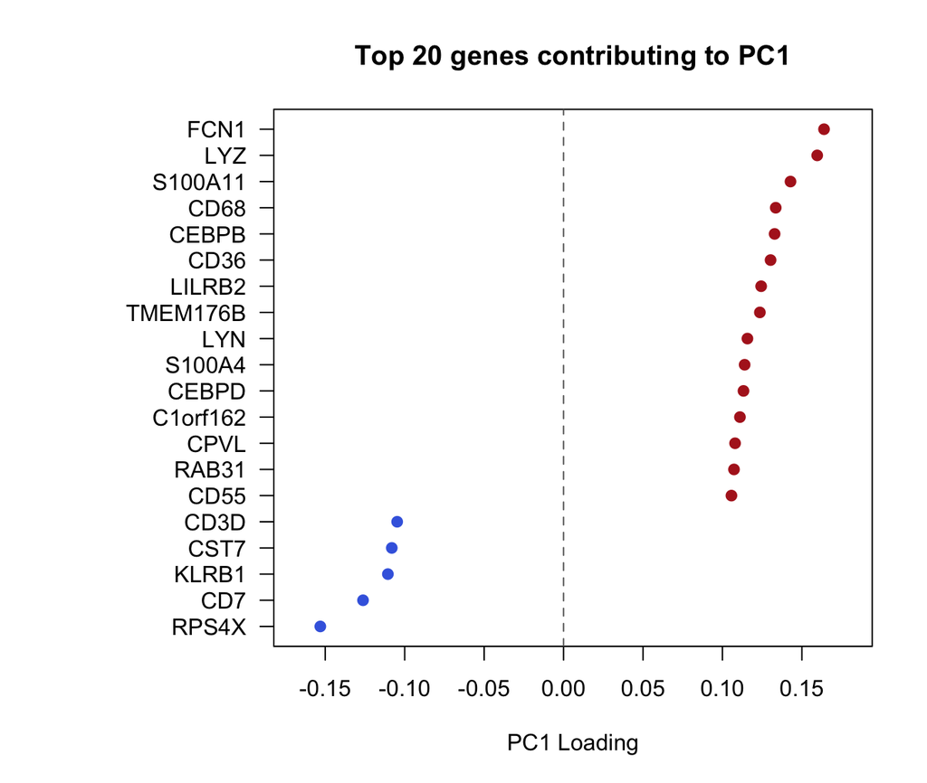

```r
# Get PC1 loadings (one per gene).
pc1_loadings <- res_pca$rotation[, 1]  # PC1 is the first column.

# Sort by absolute value and extract top 20 genes.
top_gene_indices <- order(abs(pc1_loadings), decreasing = TRUE)[1:20]
top_genes <- names(pc1_loadings)[top_gene_indices]
top_loadings <- pc1_loadings[top_gene_indices]

# Reorder genes for plotting from low to high loading.
sorted_order <- order(top_loadings)
top_genes_sorted <- top_genes[sorted_order]
top_loadings_sorted <- top_loadings[sorted_order]

# Set margins for gene labels.
par(mar = c(5, 10, 4, 2))

# Plot as a dot plot
plot(top_loadings_sorted,
     seq_along(top_genes_sorted),
     pch = 19,
     col = ifelse(top_loadings_sorted > 0, "firebrick", "royalblue"),
     xlab = "PC1 Loading",
     ylab = "",
     yaxt = "n",
     main = "Top 20 genes contributing to PC1",
     xlim = range(top_loadings_sorted) * 1.1)

# Add gene names on y-axis.
axis(2, at = seq_along(top_genes_sorted), labels = top_genes_sorted, las = 1)

# Add a reference line at zero.
abline(v = 0, lty = 2, col = "grey40")
```

**What this shows:**

- Genes to the right of the zero line have positive PC1 loadings – they contribute positively to the PC1 direction.
- Genes to the left have negative PC1 loadings – they contribute in the opposite direction.
- Dot colour helps distinguish this visually: `firebrick` (red) for positive, `royalblue` for negative.
- This plot helps us understand which genes are most associated with variation along PC1. Genes on the right (such as CD68, CD36) are active in cells with high PC1 scores, while those on the left are active in cells with low PC1 scores.

## 7.4 Save point (3)

Save the R objects.

```r
saveRDS(counts_log, file = "backup/003_pbmc_counts_log.rds")
saveRDS(res_pca, file = "backup/003_pbmc_res_pca.rds")
```

To resume later:

```r
counts_log <- readRDS("backup/003_pbmc_counts_log.rds")
res_pca <- readRDS("backup/003_pbmc_res_pca.rds")
```

# 8 Clustering and classification

Clustering and classification of scRNA-seq data are distinct concepts. Clustering, as the name suggests, involves grouping cells into several distinct partitions. In contrast, classification refers to assigning individual cells to predefined cell types.

In typical analyses, clustering of cell populations is performed first. Subsequently, the cell type of each cluster is inferred to classify the cells.

**Research question:** How can we classify scRNA-seq data containing uncharacterized cells, such as unexpected cancer type?

## 8.1 Cleaning up R objects

By now, you might have accumulated some unnecessary R objects. You can clear these objects using the following command or by clicking the brush icon and the memory pie chart icon in RStudio.

[figure not shown]

[figure not shown]

```r
# Remove a specific R object.
rm(cellxgene)

# Remove all objects.
rm(list = ls())

# Release unused memory.
gc()
```

## 8.2 Unsupervised clustering

**Unsupervised clustering** in scRNA-seq is a method to group cells with similar gene expression profiles without prior labels. It helps identify cell types or states based on expression patterns alone.

Load the data.

```r
res_pca <- readRDS("backup/003_pbmc_res_pca.rds")
```

Here, we will use k-means clustering, the simplest linear classifier, to divide the cell populations distributed in the principal component space into two groups.

K-means clustering is an unsupervised algorithm that groups data into *k* clusters by minimizing the distance between data points and their respective cluster center.

```r
set.seed(1)
res_kmeans <- kmeans(res_pca$x, centers = 2)
```

The `kmeans()` function in R’s default stats package uses random numbers. To ensure reproducibility of the results, we set a seed for the random number generator using the `set.seed()` function.

Inspect the contents of `res_kmeans`:

```r
names(res_kmeans)
```

```
[1] "cluster"      "centers"      "totss"        "withinss"     "tot.withinss" "betweenss"
[7] "size"         "iter"         "ifault"
```

- **cluster:** A vector assigning each observation (i.e., cell) to one of the *k* clusters identified by the k-means algorithm. If `centers = 2`, each value in `res_kmeans$cluster` will be either 1 or 2, indicating the cluster to which that observation belongs.

Visualize these clustering results. If you’re interested, try it with *k* = 3 as well.

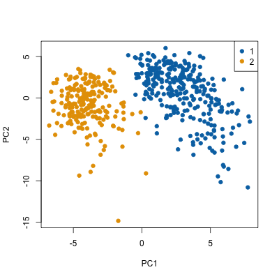

```r
color_palette <- c("#0072B2", "#E69F00", "#009E73")
cluster_labels <- res_kmeans$cluster
cluster_colors <- color_palette[cluster_labels]

plot(res_pca$x[, c(1, 2)], col = cluster_colors, pch = 19)
legend("topright", legend = sort(unique(cluster_labels)),
       col = color_palette[sort(unique(cluster_labels))], pch = 19)
```

From the plot, you can see that two major cell populations have been identified. It’s important to note that this partitioning isn’t just based on visual separation but rather on differences in their gene expression profiles.

## 8.3 Saving figures in base R

To save plots created with base R functions, use the built-in `png()` or `pdf()` functions. These functions open a graphics device that captures all plots until you call `dev.off()`.

```r
# Create a new folder "figures/" in the current working directory.
dir.create("figures", showWarnings = FALSE)

# Open a PNG graphics device
png("figures/pca_kmeans_plot.png", width = 400, height = 400)

# Create the plot
plot(res_pca$x[, c(1, 2)], col = cluster_colors, pch = 19)
legend("topright", legend = sort(unique(cluster_labels)),
       col = color_palette[sort(unique(cluster_labels))], pch = 19)

# Close the device and save the file
dev.off()
```

**Note:** Always call `dev.off()` to properly close the file. Otherwise, the image may be incomplete or not saved at all.

## 8.4 Save point (4)

Save the R objects.

```r
saveRDS(res_kmeans, file = "backup/004_pbmc_res_kmeans.rds")
```

To resume later:

```r
res_kmeans <- readRDS("backup/004_pbmc_res_kmeans.rds")
```

# 9 Statistical test

Clear all objects and load the necessary data:

```r
rm(list = ls())
counts_log <- readRDS("backup/003_pbmc_counts_log.rds")
res_pca <- readRDS("backup/003_pbmc_res_pca.rds")
res_kmeans <- readRDS("backup/004_pbmc_res_kmeans.rds")
```

## 9.1 Wilcoxon rank-sum test

Here, we will perform a statistical test to identify the cell type composition of the two clusters obtained from the k-means method (with *k* = 2).

The principle is quite straightforward. Comparing the expression levels of a monocyte marker gene, such as CD68, between the two groups should reveal the identity.

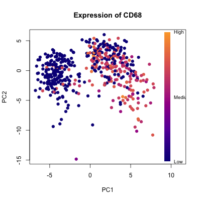

```r
# Import functions for visualisation from R/myplot.R.
source("R/myplot.R")

scatter_w_gradient(
  dataframe2D = res_pca$x[, c(1, 2)], mat = counts_log, gene = "CD68")
```

Based on this result, we can hypothesize that Cluster 1 represents monocytes. While such observations are useful, we need objective measures to draw more convincing conclusions. Below, we’ll perform statistical tests on the expression of all genes between Cluster 1 and Cluster 2 to characterize the cell populations comprehensively.

First, let’s prepare a data frame to store the results.

```r
res_stat <- data.frame(cluster = "1", log2FC = NA_real_,
                       p_value = NA_real_, p_value_adjusted = NA_real_,
                       gene = rownames(counts_log), stringsAsFactors = FALSE)
```

```r
View(head(res_stat))
```

| cluster | log2FC | p_value | p_value_adjusted | gene |
| --- | --- | --- | --- | --- |
| 1 | NA | NA | NA | UBE2E2 |
| 1 | NA | NA | NA | SH3YL1 |
| 1 | NA | NA | NA | HMGXB4 |
| 1 | NA | NA | NA | CYSTM1 |
| 1 | NA | NA | NA | ANP32B |
| 1 | NA | NA | NA | ZMAT3 |

- The first column, “cluster”, indicates that the two-group comparison statistical test in that row is performed against the cluster with this label.
- The second column, “log2FC”, will contain the log2 fold change, which tells us if the gene’s expression in this cluster is higher or lower compared to the other cluster. Currently, it’s filled with `NA_real_`, representing a numeric missing value.
- The third column, “p_value”, will hold the p-value calculated from our two-group comparison test. The p-value indicates the “probability” of observing the expression differences between the clusters by chance (note that p-value itself is not a probability). A smaller p-value suggests that the difference is less likely due to random variation, implying a statistically significant difference. You’ll get a better understanding of this as you work through more single-cell analysis.
- The fourth column, “p_value_adjusted”, will contain the adjusted p-value to account for multiple testing. When we perform many tests (in this case, for each gene), the likelihood of observing a significant result by chance increases. Multiple testing correction methods calculate adjusted p-values that consider the number of tests performed.

Next, the following `for` loop automates the row-by-row processing of the `res_stat` data frame.

```r
clusters <- res_kmeans$cluster
ngenes <- nrow(res_stat)

for(i in seq_len(ngenes)){
  gene_expr <- counts_log[i, ]
  group1 <- gene_expr[clusters == 1]
  group2 <- gene_expr[clusters == 2]

  # Calculate mean expression per cluster.
  mean1 <- mean(group1)
  mean2 <- mean(group2)

  # Calculate log2 fold change (add a small pseudocount 1e-6 to avoid log2(0)).
  res_stat$log2FC[i] <- log2(mean1 + 1e-6) - log2(mean2 + 1e-6)

  # Perform Wilcoxon rank-sum test with error handling:
  # Attempt to run the test, storing the result (error or success) in `res_test`.
  res_test <- try(wilcox.test(group1, group2), silent = TRUE)

  # If an error occurs, assign NA to the p-value;
  # otherwise, assign the test's p-value.
  if(inherits(res_test, "try-error")){
    res_stat$p_value[i] <- NA_real_
  }else{
    res_stat$p_value[i] <- res_test$p.value
  }
}

# Adjust p-values to account for multiple testing using Bonferroni correctin.
res_stat$p_value_adjusted <- p.adjust(res_stat$p_value, method = "bonferroni")

# Select the lines in which log2FC is positive.
res_stat <- res_stat[which(res_stat$log2FC > 0), ]
```

Here, Wilcoxon rank-sum test is one of the nonparametric test that does not assume normal distribution for the observed (cell) data, which is often used in scRNA-seq data analysis.

Finally, sort `res_stat` by adjusted p-value ascending.

```r
res_stat_sorted <- res_stat[order(res_stat$p_value), ]
# Optional: Sorting the rownames.
rownames(res_stat_sorted) <- seq_len(nrow(res_stat_sorted))
```

```r
View(head(res_stat_sorted, n = 10))
```

| cluster | log2FC | p_value | p_value_adjusted | gene |
| --- | --- | --- | --- | --- |
| 1 | 0.9583620 | 2.10e-58 | 1.04e-55 | LYZ |
| 1 | 1.1899840 | 7.86e-49 | 3.90e-46 | FCN1 |
| 1 | 0.6825742 | 2.07e-47 | 1.03e-44 | S100A11 |
| 1 | 0.2364019 | 1.89e-33 | 9.37e-31 | S100A4 |
| 1 | 2.7405417 | 1.15e-26 | 5.70e-24 | CD68 |
| 1 | 2.5639564 | 1.07e-24 | 5.30e-22 | CD36 |
| 1 | 1.6291348 | 7.11e-23 | 3.53e-20 | CEBPB |
| 1 | 2.8257220 | 1.58e-21 | 7.82e-19 | TMEM176B |
| 1 | 1.9647192 | 2.31e-21 | 1.15e-18 | CEBPD |
| 1 | 2.8916685 | 1.69e-19 | 8.40e-17 | LILRB2 |

## 9.2 Statistical pitfalls

Now, let’s recall the question posed earlier in “Observation”:

Imagine you test whether a gene is expressed differently in two groups and get a p-value of 0.01.  
Is that enough to say the difference is real?

For example, in `res_stat`, the adjusted p-value for MTDH expression is around 0.008, but visualizing its expression level shows the following:

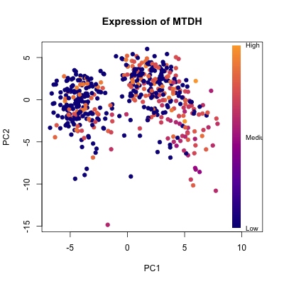

For this gene, a significant expression difference between Cluster 1 and Cluster 2 isn’t visually convincing.

Now, what about S100A4 (adjusted p-value < 1e-30)?

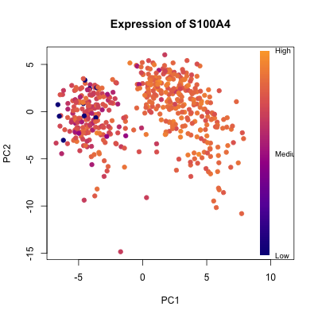

Again, the difference is subtle.

These results are common in scRNA-seq data analysis. One key point is that p-values tend to decrease with larger sample sizes (cell numbers). With around 500 cells, a significance threshold of 0.01 might be too lenient. Note that significance levels of 0.01 or 0.05 are often used with smaller sample sizes (e.g., around 6 or 10, like the number of mice in an experiment).

Another crucial point in two-group comparisons is to consider the log2 fold change alongside the p-value. In the S100A4 example, the log2FC was approximately 0.2, which wasn’t a difference large enough to be immediately clear visually.

So, how can we avoid these statistical pitfalls? As we’ve already discussed:

**“Data analysis tends to fail if you try to take shortcuts.”**

When in doubt, visualize it.

## 9.3 Save point (5)

Save the R objects.

```r
saveRDS(res_stat_sorted, file = "backup/005_pbmc_res_stat_sorted.rds")
```

To resume later:

```r
res_stat_sorted <- readRDS("backup/005_pbmc_res_stat_sorted.rds")
```

# 10 Cell type annotation

Based on the `res_stat_sorted`, we will now assign cell type identities to Cluster 1. This process of assigning labels is called annotation (e.g., annotating Cluster 1 as “monocyte”).

The practical steps for annotation are as follows:

1. **Gain a deep understanding of your data.** If it’s your own data, refer to preliminary experimental results. For public datasets, identify potential cell types from the original publication. In this case, [Reyes et al., Nature Medicine, 2020](https://pubmed.ncbi.nlm.nih.gov/32066974/), possible cell types include monocyte, T cell, B cell, NK cell, and dendritic cell.
2. **Select around 10 genes with large log2 fold change and small p-values that appear to be immune cell markers.** Investigate their cellular functions using literature searches. Databases like [GeneCards](https://www.genecards.org/) are useful for quickly linking gene names to cellular functions.
3. **Once you find 2-3 strong marker genes, you can determine the cell type.** In this case, we will annotate Cluster 1 based on information from monocyte marker genes such as CD68 and CD36.
4. **Define significance thresholds.** For example, `log2FC` > 1 and `p_value_adjusted` < 1e-20.
5. **Annotate other clusters using the same significance thresholds.**

Based on the above, we’ve identified Cluster 1 as likely being the monocyte population. Now, let’s reflect this result in `meta_qc3` data to perform cell type annotation.

Clear all objects and load the necessary data:

```r
rm(list = ls())
meta_qc3 <- readRDS("backup/002_pbmc_meta_afterQC.rds")
res_kmeans <- readRDS("backup/004_pbmc_res_kmeans.rds")
```

First, let’s confirm that `res_kmeans$cluster` links cell barcodes to their clustering labels.

```r
head(res_kmeans$cluster)
```

```
GTACTCCGTCTAGGTT.17 TCTGAGAGTTCAACCA.15 AGCGTCGGTTCCGGCA.11 GGGATGATCTTTAGGG.13
                  1                   1                   2                   2
AGATTGCAGATATGGT.15 TTGAACGGTTCCACAA.13
                  1                   1
```

Next, we’ll verify that these cell barcodes match the row names of `meta_qc3`.

```r
identical(rownames(meta_qc3), names(res_kmeans$cluster))
```

```
[1] TRUE
```

Finally, we’ll add a new column named `cell_type` to `meta_qc3` and assign “monocyte” to the cells belonging to Cluster 1.

```r
# Copy meta_q3 to meta_annotated.
meta_annotated <- meta_qc3

# Add a new column to `meta_annotated`.
meta_annotated$cell_type <- NA_character_

# Get indices of cells, whose clustering label is "1".
indices3_cell <- which(res_kmeans$cluster == 1)

# Annotating Cluster 1 as "monocyte".
meta_annotated$cell_type[indices3_cell] <- "monocyte"
```

With this, the annotation of Cluster 1 is complete.

```r
View(meta_annotated)
```

|  | Donor | Group | nReads | percMT | cell_type |
| --- | --- | --- | --- | --- | --- |
| GTACTCCGTCTAGGTT.17 | C2P18 | Sepsis_moderate | 744 | 25.80645 | monocyte |
| TCTGAGAGTTCAACCA.15 | C2P10H | Control | 207 | 31.88406 | monocyte |
| AGCGTCGGTTCCGGCA.11 | P02H | Control | 243 | 35.39095 | NA |
| GGGATGATCTTTAGGG.13 | C2P10 | Sepsis_severe | 179 | 40.22346 | NA |
| AGATTGCAGATATGGT.15 | C2P15 | Sepsis_moderate | 228 | 39.91228 | monocyte |
| TTGAACGGTTCCACAA.13 | C2P13 | Sepsis_severe | 491 | 40.52953 | monocyte |

## 10.1 Save point (6)

Save the R objects.

```r
saveRDS(meta_annotated, file = "backup/006_pbmc_meta_annotated.rds")
```

To resume later:

```r
meta_annotated <- readRDS("backup/006_pbmc_meta_annotated.rds")
```

# 11 Monocyte population

In this section, we explore the link between sepsis and monocyte levels. According to [Reyes et al., Nature Medicine, 2020](https://pubmed.ncbi.nlm.nih.gov/32066974/), as sepsis progresses and inflammation increases, the proportion of monocytes among all immune cells also rises.

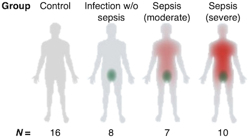

Let’s check if this observation holds true. You may notice that the code below uses some advanced functions (such as `tapply` and `match`). Although they might seem technical, don’t worry too much about the details—they help us summarise the data efficiently.

**For a beginner:** Just focus on the idea: we calculate the fraction of monocytes for each donor and then compare these fractions across different clinical groups using a boxplot.

```r
# Step 1: Get unique Donor-Group pairs.
donor_groups <- unique(meta_annotated[, c("Donor", "Group")])

# Step 2: Count total cells and monocytes per Donor.
monocyte_fraction <- tapply(meta_annotated$cell_type == "monocyte",
                            meta_annotated$Donor,
                            function(x) sum(x, na.rm = TRUE) / length(x))

# Step 3: Merge with Group info.
group_labels <- donor_groups$Group[match(names(monocyte_fraction),
                                         donor_groups$Donor)]

# Step 4: Combine into a data frame for plotting.
plot_data <- data.frame(Donor = names(monocyte_fraction),
                        Group = group_labels,
                        MonocyteFraction = as.numeric(monocyte_fraction),
                        stringsAsFactors = FALSE)

# Step 5: Factorize Group in desired order.
levels <- c("Control", "Infection", "Sepsis_moderate", "Sepsis_severe")
plot_data$Group <- factor(plot_data$Group, levels = levels)

# Step 6: Plot
boxplot(MonocyteFraction ~ Group, data = plot_data,
        main = "", ylab = "Monocyte Fraction", xlab = "",
        col = "gray90", border = "gray40")
```

**Additional Note on the Code:** Understanding tapply and match:

- The `tapply` function here groups the cells by donor and calculates the fraction of cells labelled as “monocyte” for each donor.
- The `match` function then helps to assign each donor the correct clinical group.

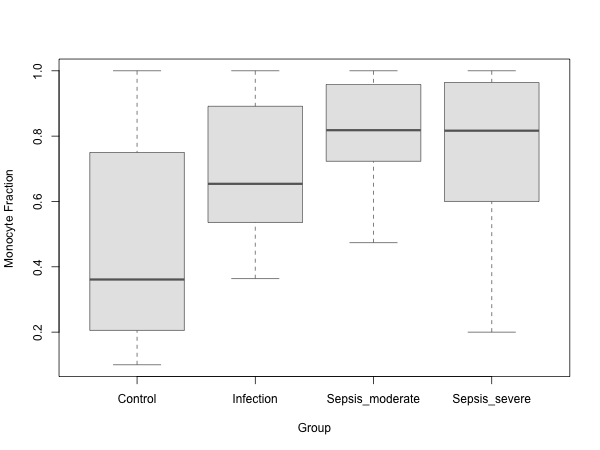

While monocytes increase with inflammation, some evidence suggests they may not increase further or might even slightly decrease in severe sepsis ([Iida et al., Bioinformatics, 2022](https://pubmed.ncbi.nlm.nih.gov/35924984/)).

# 12 Discussion

This tutorial introduced the basics of single-cell RNA-seq (scRNA-seq) data analysis using only built-in R functions.

For those who wish to perform more advanced or scalable analyses, learning [Seurat](https://satijalab.org/seurat/) is recommended. You may find that, at its core, the analytical logic is very similar to what you experienced here. However, techniques such as variable feature selection and advanced visualisation often lead to better clustering performance, as illustrated below:

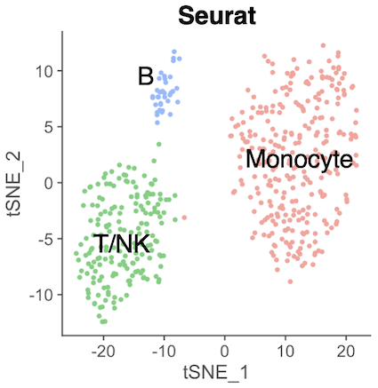

Throughout this hands-on session, you may have encountered moments of confusion or felt certain limitations in the tools we used.

To wrap up, here are a few technical notes and future considerations:

1. Since `counts` and `meta` shared the same cell barcodes, filtering out low-quality cells required removing them from both objects — an error-prone task. To avoid this, standard scRNA-seq analysis often uses the `SingleCellExperiment` class, which keeps counts, gene info, and cell metadata in sync.
2. While we separated monocytes from others, could finer annotation be achieved? If marker genes fail to appear — even after adjusting p-values — how should we proceed? A tricky but important issue.
3. Our PCA distinguished monocytes in the PC1–PC2 space. Can we go further and reduce this to a single dimension? A classic challenge in dimensionality reduction.
4. Try summarising your findings and think about how they could guide improvements in your own workflow.

Back Next